```python
from sklearn.linear_model import LinearRegression, LassoCV
from sklearn.ensemble import RandomForestRegressor
from sklearn.model_selection import cross_val_score, cross_val_predict, train_test_split
from sklearn.metrics import mean_squared_error, r2_score
from sklearn.decomposition import PCA
from sklearn.preprocessing import StandardScaler

import tensorflow as tf
from tensorflow.keras.losses import CategoricalCrossentropy
from tensorflow import keras
from tensorflow.keras import layers
from tensorflow.keras.layers import Input, Dense

import pandas as pd
import numpy as np
from matplotlib  import pyplot as plt
import seaborn as sns

#from car_price_prossessing_functions import *
from data_preprocessing import *
```

# Fonctions utiles

```python
from sklearn.linear_model import LassoCV
from sklearn.metrics import mean_squared_error, r2_score
import warnings
from sklearn.exceptions import ConvergenceWarning
from sklearn.preprocessing import StandardScaler


def CV_Lasso_from_sklearn(X_train, X_test, Y_train, Y_test, nb_cores=5):

    """
    Run a lasso-regularized linear regression with cross validation using the LassoCV from scikitlearn in python

    Arguments:
        - X_train, X_test (pd.Dataframe objects): training and test regressors
        - Y_train, Y_test (pd.Series objects): training and test target
        - nb_cores (int): number of cpu cores to be used in  parallel computing

    Returns:
        - best_alpha (float): the best lasso parameter with minimum out-of-sample score, chosen from a grid.
        - coefs (pd.Dataframe with a single column): coefficient estimates from LassoCV
        - Y_train_pred, Y_test_pred (pd.Series objects): predicted target in training and test samples

    Note:
        - Here alpha refers to the Lasso regularization parameter
    """

    scaler = StandardScaler().fit(X_train)
    X_train_1 = pd.DataFrame(scaler.transform(X_train), index = X_train.index, columns=X_train.columns)
    X_test_1 = pd.DataFrame(scaler.transform(X_test), index = X_test.index, columns=X_test.columns)

    model = LassoCV(cv=10, alphas=np.power(2.0, np.linspace(-15, 1, 100)), max_iter=5000, random_state=10101, n_jobs=nb_cores)

    with warnings.catch_warnings(record=True) as w:
        warnings.simplefilter("once", ConvergenceWarning)
        model.fit(X_train_1, Y_train)

        # If any ConvergenceWarnings were raised
        if any(issubclass(warning.category, ConvergenceWarning) for warning in w):
            print("\n⚠️ Warning: Lasso did not converge for some alpha values\n")

    # Best alpha selected
    best_alpha = model.alpha_
    print(f"Best Lasso regularization parameter: {best_alpha}")

    #Get coefs
    coefs = [model.intercept_]+list(model.coef_)
    coefs = pd.DataFrame(
        np.array(coefs).reshape((X_train_1.shape[1]+1, 1)),
        columns=['Coefs'], index=['(Intercept)']+list(X_train_1.columns)
    )

    # Predict on train and test sets
    Y_train_pred = model.predict(X_train_1)
    Y_test_pred = model.predict(X_test_1)
    Y_train_pred = pd.Series(Y_train_pred, name=Y_train.name)
    Y_test_pred = pd.Series(Y_test_pred, name=Y_test.name)

    # 6. Plot CV MSE vs log(alpha)
    mean_mse = model.mse_path_.mean(axis=1)
    std_mse = model.mse_path_.std(axis=1)
    log_alphas = np.log2(model.alphas_)

    plt.plot(log_alphas, mean_mse, label='Mean CV MSE', marker='o')
    plt.fill_between(log_alphas, mean_mse - std_mse, mean_mse + std_mse, color='lightgray', label='±1 std dev')
    plt.axvline(np.log2(best_alpha), linestyle='--', color='red', label=f'Best lambda = {best_alpha:.5f}')
    plt.xlabel('Log2(Alpha)')
    plt.xlabel('Log2(Alpha)')
    plt.ylabel('Mean Squared Error (CV)')
    plt.title('LassoCV: CV Error vs log2(Regularization Strength)')
    plt.legend()
    plt.grid(True)
    plt.tight_layout()
    plt.show()

    return best_alpha, coefs, Y_train_pred, Y_test_pred
```

```python
import rpy2.robjects as robjects
from rpy2.robjects import pandas2ri
from rpy2.robjects.conversion import localconverter
import matplotlib.image as mpimg
import matplotlib.pyplot as plt

def CV_Lasso_from_R_glmnet(X_train, X_test, Y_train, Y_test, nb_cores = 3):

    """
    Run a lasso-regularized linear regression with cross validation using cv.glmnet from R

    Arguments:
        - X_train, X_test (pd.Dataframe objects): training and test regressors
        - Y_train, Y_test (pd.Series objects): training and test target
        - nb_cores (int): number of cpu cores to be used in  parallel computing

    Returns:
        - lambda_chosen (float): the best lasso parameter with minimum out-of-sample score, chosen from a grid.
        - coefs (pd.Dataframe with a single column): coefficient estimates from LassoCV
        - Y_train_pred, Y_test_pred (pd.Series objects): predicted target in training and test samples

    Note:
        - Here lambda refers to the Lasso regularization parameter
    """

    R_script = \
    \
    """

    library(glmnet)
    library(doParallel)

    set.seed(10101)

    penalty.factor = rep(1, ncol(X_train))

    lambda_grid <- 2^seq(-15, 1, length.out = 100)

    cl <- makeCluster(nb_cores)
    registerDoParallel(cl)

    cv_fit <- cv.glmnet(
      x = as.matrix(X_train),
      y = Y_train,
      nfolds = 10,
      alpha = 1.0,
      lambda = lambda_grid,
      penalty.factor = penalty.factor,
      parallel = TRUE,

      )

    stopCluster(cl)

    # Save the plot
    png("cv_fit_plot.png", width = 1200, height = 1000, res = 200)
    plot(cv_fit)
    dev.off()

    lambda_chosen <- cv_fit$lambda.min
    coef_matrix <- coef(cv_fit, s = lambda_chosen)
    coefs <- as.matrix(coef_matrix)
    coefs <- as.data.frame(coefs)
    colnames(coefs) <- 'Coefs'
    Y_train_pred <- c(predict(cv_fit, newx = as.matrix(X_train), s = lambda_chosen))
    Y_test_pred <- c(predict(cv_fit, newx = as.matrix(X_test), s = lambda_chosen))

    """

    #pandas2ri.activate()
    with localconverter(robjects.default_converter + pandas2ri.converter):
        robjects.globalenv['X_train'] = robjects.conversion.py2rpy(X_train)
        robjects.globalenv['X_test'] = robjects.conversion.py2rpy(X_test)
        robjects.globalenv['Y_train'] = robjects.conversion.py2rpy(Y_train)

    robjects.globalenv['nb_cores'] = robjects.IntVector([nb_cores])[0]

    robjects.r(R_script)

    with localconverter(robjects.default_converter + pandas2ri.converter):
        coefs = robjects.conversion.rpy2py(robjects.globalenv['coefs'])
        Y_train_pred = robjects.conversion.rpy2py(robjects.globalenv['Y_train_pred'])
        Y_test_pred = robjects.conversion.rpy2py(robjects.globalenv['Y_test_pred'])
        lambda_chosen = robjects.conversion.rpy2py(robjects.globalenv['lambda_chosen'])

    Y_train_pred = pd.Series(Y_train_pred, name=Y_train.name)
    Y_test_pred = pd.Series(Y_test_pred, name=Y_test.name)

    #Show CV values for lambda
    img = mpimg.imread('cv_fit_plot.png')
    plt.imshow(img)
    plt.axis('off')
    plt.show()

    return lambda_chosen, coefs, Y_train_pred, Y_test_pred
```

```python
def plot_true_predicted(Y_true, Y_pred, VarName=""):
    """
    Show scatter plot of two pd.Series: Y_true in x-axis, Y_pred in y-axis
    """

    r2_test = r2_score(Y_test, Y_test_pred)

    sns.scatterplot(x=Y_test, y=Y_test_pred)

    plt.plot(Y_test, Y_test, linestyle='--', color='gray')

    plt.xlabel(f"True {VarName}"); plt.ylabel(f"Predicted {VarName}")

    plt.title(f"Price prediction in test sample \n(Test R² = {round(r2_test,4)})")

    plt.show()
```

```python
import scipy.stats as stats

def ratio_coefs_pvalue(var1, var2, params, cov):

    """
    Compute the p-value of a ratio statistic  params[var1]/params[var2] using the Delta Method approximation of its variance

    Arguments:
        - var1, var2 (string objects): names of the two statistics that have estimated values in params
        - params (pd.Series): observed value of a real vector-valued estimator
        - cov (pd.DataFrame): observed value of the variance-covariance matrix of params
    Returns:
        - pvalue (float object)

    Note:
        - Delta method approximation of var_(a/b) =  (1 / b**2) * var_a + (a**2 / b**4) * var_b - (2 * a / b**3) * cov_ab
    """

    if var1==var2:
        pvalue=0
    else:
        # Compute the ratio and its standard error using the Delta Method
        a = params[var1]
        b = params[var2]
        var_a = cov.loc[var1, var1]
        var_b = cov.loc[var2, var2]
        cov_ab = cov.loc[var1, var2]
        ratio = a / b
        var_ratio = (1 / b**2) * var_a + (a**2 / b**4) * var_b - (2 * a / b**3) * cov_ab
        se_ratio = var_ratio**0.5

        #  Compute the z-statistic and p-value

        z = (ratio - 1) / se_ratio  # Test if ratio == 1
        pvalue = 2 * (1 - stats.norm.cdf(abs(z)))

    return pvalue
```

```python
def regress_demand(X_train, Y_train, price_train_predicted=None):

    """
    OLS-estimate a demand model with a simple logit specification, i.e. Log(S)-Log(S_o) = X'Betax + Betap*P + epsilon

    Arguments:
        - X_train (pd.DataFrame object): matrix of regressors, including the 'sellingprice' column
        - Y_train (pd.Series): dependant variable column, Log(S)-Log(S_o)
        - price_train_predicted (None or pd.Series): an exogenous prediction of the 'sellingprice' column
            - if pd.Series, then the 'sellingprice' column in X_train will be replaced by price_train_predicted before estimation
                - the resulting econometric method is a 2SLS where the price is endogenous
            - if None, then the 'sellingprice' column in X_train remains unchanged
                - the resulting econometric method is an OSL where the price is exodogenous

    Returns:
        - model (object of class statsmodels.regression.linear_model.RegressionResultsWrapper): the estimated model
        - coefs (pd.DataFrame): dataframe with
            - estimated coefficients and their pvalues,
            - estimated marginal willingnesses to pay and their pvalues
        - Y_train_pred (pd.Series): prediction of dependent column in training sample

    Note:
        - the willingness to pay associated with a product attribute k in X is the ratio between the coef of k and the coef of the 'sellingprice' column
    """

    X_train_new = X_train.copy()

    if ~np.all(price_train_predicted==None):
        X_train_new[price_train_predicted.name] = price_train_predicted

    model = sm.OLS(Y_train, sm.add_constant(X_train_new)).fit()

    #print(model.summary())

    Y_train_pred = model.predict(sm.add_constant(X_train_new))

    coefs = model.params

    cov = model.cov_params()

    WTP_pvalue = pd.Series(
        model.params.index.map(lambda var1: ratio_coefs_pvalue(var1, 'sellingprice', coefs, cov)),
        index=model.params.index
    )

    # Merge coefs, WTP (willingness to pay) and their pvalues
    coefs = pd.concat([coefs, model.pvalues,  coefs/np.abs(coefs['sellingprice']), WTP_pvalue], axis=1)
    coefs.columns = ['coef','coef-pvalue','wtp','wtp-pvalue']

    return model, coefs, Y_train_pred
```

```python
def plot_coefs(coef_series, pvalue_series, titlename):

    """
    Shows a graph, in annotated bar plots, of observed values of a vector-valued statistic with the corresponding pvalues
    """

    # pvalue_stars
    pvalue_stars_series = pvalue_series.map(
        lambda x: '****' if x<0.001 else ('***' if x<0.01 else ('  **' if x<0.05 else ('   *' if x<0.1 else '      ')))
    )

    # Create a figure and axis
    fig, ax = plt.subplots(figsize=(10, 7))

    # Plot the bars with color based on value
    bars = ax.bar(coef_series.index, [0.1 if v>=0 else -0.1 for v in coef_series],  # All bars have the same length
                  color=['#4c72b0' if v >= 0 else '#c44e52' for v in coef_series])

    # Add true value labels on top of the bars
    ax.bar_label(
        bars, labels=[f'{coef_series[name]:.3f} {pvalue_stars_series[name]}' for name in coef_series.index],
        padding=3, fontsize=10, rotation=90
    )

    # Add title and labels
    ax.set_title(f"{titlename} \n\n(****: pvalue < 0.001, ***: pvalue < 0.01, **: pvalue < 0.05, *: pvalue < 0.1)\n")
    ax.set_xlabel("Product Attribute")
    ax.set_ylabel("")
    ax.axhline(0, color='black', linewidth=0.8)


    # Rotate x-axis labels for better readability
    plt.xticks(rotation=90)

    # Remove y ticks
    ax.set_yticks([])

    ax.set_ylim((-.22,.22))

    # Adjust layout to prevent clipping
    plt.tight_layout()

    plt.show()
```

```python
def random_forest(X_train, X_test, Y_train, Y_test, nb_cores=3, max_vars_per_tree=1.0):

    """
    Run a random forest regression model using RandomForestRegressor from scikitlearn

    Arguments:
        - X_train, X_test (pd.Dataframe objects): training and test regressors
        - Y_train, Y_test (pd.Series objects): training and test target columns
        - nb_cores (int): number of cpu cores to be used in  parallel computing
        - max_vars_per_tree (same class as the max_features argument in RandomForestRegressor):
            - maximum number of variables considered during randon selection of variables in X_train at each stage in each tree

    Returns:
        - Y_train_pred, Y_test_pred (pd.Series objects): predicted target in training and test samples
    """

    # Initialize Random Forest Regressor
    rf = RandomForestRegressor(n_estimators=200, random_state=42, max_features=max_vars_per_tree, n_jobs=nb_cores)

    # Cross-validation scores (R² by default)
    cv_scores = cross_val_score(rf, X_train, Y_train, cv=5, scoring='r2', n_jobs=nb_cores)

    # Cross-validated predictions
    Y_train_pred = cross_val_predict(rf, X_train, Y_train, cv=5, n_jobs=nb_cores)
    Y_test_pred = cross_val_predict(rf, X_test, Y_test, cv=5, n_jobs=nb_cores)

    Y_train_pred = pd.Series(Y_train_pred, name=Y_train.name)
    Y_test_pred = pd.Series(Y_test_pred, name=Y_test.name)

    return Y_train_pred, Y_test_pred
```

```python
def deep_nn(X_train, X_test, Y_train, Y_test, loss='mae', hiden_layer_size=None):

    """
    Run a deep learning regression model with sequential and connected layers using tensorflow and keras

    Arguments:
        - X_train, X_test (pd.Dataframe objects): training and test regressors
        - Y_train, Y_test (pd.Series objects): training and test target columns
        - nb_cores (int): number of cpu cores to be used in  parallel computing
        - loss (string): the loss function to minimize during the regression
        - hiden_layer_size (int): number of hidden layers
        - max_vars_per_tree (same class as the max_features argument in RandomForestRegressor):
            - maximum number of variables considered during randon selection of variables in X_train at each stage in each tree

    Returns:
        - Y_train_pred, Y_test_pred (pd.Series objects): predicted target in training and test samples
    """

    if hiden_layer_size==None:
        hiden_layer_size = X_train.shape[1]

    scaler = StandardScaler().fit(X_train)
    X_train_1 = pd.DataFrame(scaler.transform(X_train), index = X_train.index, columns=X_train.columns)
    X_test_1 = pd.DataFrame(scaler.transform(X_test), index = X_test.index, columns=X_test.columns)

    nnmodel = keras.Sequential([
        Input(shape=(X_train.shape[1],)),
        layers.Dense(hiden_layer_size, activation='relu'),
        layers.Dense(hiden_layer_size, activation='relu'),
        layers.Dense(hiden_layer_size, activation='relu'),
        layers.Dense(hiden_layer_size, activation='relu'),
        layers.Dense(1)])
    nnmodel.compile(optimizer='adam',
                  loss=loss,       # Mean Absolute Error for regression (is more robust to outliers, but slower)
                  metrics=['mse']   # Mean Squared Error for evaluation
                 )

    print(nnmodel.summary())

    nnmodel.fit(X_train_1, Y_train, epochs=100, batch_size=32, validation_split=0.2, verbose=False)

    Y_train_pred = pd.Series(nnmodel.predict(X_train_1)[:,0], name=Y_train.name)
    Y_test_pred = pd.Series(nnmodel.predict(X_test_1)[:,0], name=Y_test.name)

    return Y_train_pred, Y_test_pred
```

```python
def pca(X_train, X_test, variance_ratio_preserved=1.0):


    """
    Get PCA representation of data that preserve a given variance ratio of the original data

    Arguments:
        - X_train, X_test (pd.Dataframe objects): training and test data
        - variance_ratio_preserved (float): the ratio of variance to be preserved in the PCA embeddings
    Returns:
        - X_train_pred, X_test_pred (pd.DataFrame objects): PCA components that represent the original training and test data in a lower-dimensional space
    """


    # Standardize the features
    scaler = StandardScaler()
    X_train_scaled = scaler.fit(X_train)
    X_train_scaled = scaler.transform(X_train)
    X_test_scaled = scaler.transform(X_test)

    # Apply PCA
    pca = PCA(n_components=X_train_scaled.shape[1])
    X_train_pred = pca.fit_transform(X_train_scaled)
    X_test_pred = pca.transform(X_test_scaled)

    # Extract selected pca components based on the variance ratio

    x=np.arange(len(pca.explained_variance_ratio_))
    y=pca.explained_variance_ratio_
    nb_selected_components = len(y.cumsum()[y.cumsum()<=variance_ratio_preserved])
    print(f"\nThe first {nb_selected_components} components have a total variance ratio of {variance_ratio_preserved}\n")
    X_train_pred = pd.DataFrame(
        X_train_pred[:,:nb_selected_components], index=X_train.index, columns=[f"PC_{i+1}" for i in range(nb_selected_components)]
    )
    X_test_pred = pd.DataFrame(
        X_test_pred[:,:nb_selected_components], index=X_test.index, columns=[f"PC_{i+1}" for i in range(nb_selected_components)]
    )

    ## Plot the explained variance ratio of all pca components

    fig, ax = plt.subplots()
    # First plot on left y-axis
    line1 = sns.lineplot(x=x, y=y, ax=ax, color='blue', label='Explained variance ratio')
    ax.set_xlabel('Component index')
    ax.set_ylabel('Explained variance ratio')
    # Second plot on right y-axis
    ax2 = ax.twinx()
    line2 = sns.lineplot(x=x, y=y.cumsum(), color='orange', linestyle='--', ax=ax2, label='Cumulative explained variance ratio')
    ax2.set_ylabel('Cum. explained variance ratio')
    # Combine line handles and labels
    lines, labels = [], []
    for axis in [ax, ax2]:
        line_objs, label_list = axis.get_legend_handles_labels()
        lines.extend(line_objs)
        labels.extend(label_list)
    # Add combined legend to ax
    ax.legend(lines, labels, loc='right')
    ax2.legend(lines, labels, loc='right')
    plt.title("Explained Variance and Cumulative Variance")
    plt.show()

    return X_train_pred, X_test_pred
```

# Importation des données

```python
model_yaml_path = "config/data_config.yaml"
cars_file_path = 'car_prices.csv'
population_file_path = 'states_populations_yr2015.csv'
```

```python
config = load_config(model_yaml_path)

df = load_data(cars_file_path); pop_df = load_data(population_file_path) #.drop('population (2015)', axis=1)

df = process_dates(df)

df = define_market(
    df, market_vars=config['var_of_interest']['marketvar'],
    market_label='market', market_code='marketid', minsize=20, DropSmallMarkets=True
)

df =  preprocess_color_interior(df)

df = subset_var_of_interest(
    df,
    var_of_interest=config['var_of_interest']['numerical']+['state']+config['var_of_interest']['unordered'],
    marketvar='marketid', productvar=config['var_of_interest']['productvar'][0],
    DropNa=True
)
df = change_to_numerical(df, config['var_of_interest']['numerical'])

df = order_unorder_categorical_var(
    df, ordered=config['var_of_interest']['ordered'], unordered=config['var_of_interest']['unordered'],
    ordered_masks=config['ordered_masks'], unordered_masks=config['unordered_masks'],
    ordered_min_frequencies=config['ordered_min_frequencies'],
    unordered_min_frequencies=config['unordered_min_frequencies']
)
```

```
38 rows with invalid dates have been dropped

63 markets with sizes lower than 20 have been dropped making 485 dropped rows


Number of missing per relevant variable in the remaining dataframe
 marketid            0
make            10282
sellingprice        0
odometer           93
condition       11794
state               0
year                0
body            13174
color           25416
interior        17808
dtype: int64

A total of 60818 rows with missing data in relevant variables have been dropped
```

```python
# Check missing values
np.sum(df.isna(), axis=0)
```

```
marketid        0
make            0
sellingprice    0
odometer        0
condition       0
state           0
year            0
body            0
color           0
interior        0
dtype: int64
```

```python
#extract the final dataframe and the names of dependant, endogenous, exogenous and instruments
data,  depvars, endogvars, exogvars, instrvars, excluded_main_categories = aggregate_data(
    df, pop_df, marketvar='marketid', productvar='make', twodegree_polynomial_instruments=True,
    aggfunc='mean', numerical=config['var_of_interest']['numerical'],
    categorical=config['var_of_interest']['categorical'],
    dep=[], endog=config['var_of_interest']['endog'], exog=config['var_of_interest']['exog']
)
data.sellingprice = data.sellingprice/10000
data.odometer = data.odometer/10000
```

```python
df.head()
```

|  | marketid | make | sellingprice | odometer | condition | state | year | body | color | interior |
| --- | --- | --- | --- | --- | --- | --- | --- | --- | --- | --- |
| 0 | 9 | kia | 21500.0 | 16639.0 | 5.0 | ca | 2015 | suv | white | black |
| 1 | 9 | kia | 21500.0 | 9393.0 | 5.0 | ca | 2015 | suv | white | beige |
| 2 | 2 | bmw | 30000.0 | 1331.0 | 45.0 | ca | 2014 | sedan | gray | black |
| 3 | 2 | other | 27750.0 | 14282.0 | 41.0 | ca | 2015 | sedan | white | black |
| 4 | 9 | bmw | 67000.0 | 2641.0 | 43.0 | ca | 2014 | sedan | gray | black |

```python
data.head()
```

|  | marketid | make | state | households (2015) | allsales | share_oo | sales | share | log_share_ratio | sellingprice | ... | interior_beige*interior_beige_RivalProducts | interior_beige*interior_gray_RivalProducts | interior_beige*interior_other_RivalProducts | interior_beige*interior_tan_RivalProducts | interior_gray*interior_gray_RivalProducts | interior_gray*interior_other_RivalProducts | interior_gray*interior_tan_RivalProducts | interior_other*interior_other_RivalProducts | interior_other*interior_tan_RivalProducts | interior_tan*interior_tan_RivalProducts |
| --- | --- | --- | --- | --- | --- | --- | --- | --- | --- | --- | --- | --- | --- | --- | --- | --- | --- | --- | --- | --- | --- |
| 0 | 0 | bmw | fl | 7381270.0 | 22076 | 0.997009 | 834 | 0.000113 | -9.085228 | 2.068822 | ... | 0.411701 | 0.696724 | 0.060662 | 0.181157 | 1.563928 | 0.101406 | 0.330925 | 0.012043 | 0.028101 | 0.092141 |
| 1 | 0 | chevrolet | fl | 7381270.0 | 22076 | 0.997009 | 2435 | 0.000330 | -8.013759 | 1.376903 | ... | 0.438265 | 0.688124 | 0.080428 | 0.204128 | 1.430546 | 0.106311 | 0.335906 | 0.025813 | 0.044163 | 0.110873 |
| 2 | 0 | chrysler | fl | 7381270.0 | 22076 | 0.997009 | 719 | 0.000097 | -9.233600 | 1.157764 | ... | 0.433013 | 0.690878 | 0.081180 | 0.197768 | 1.512101 | 0.112920 | 0.326632 | 0.026296 | 0.044009 | 0.105088 |
| 3 | 0 | dodge | fl | 7381270.0 | 22076 | 0.997009 | 1250 | 0.000169 | -8.680562 | 1.174902 | ... | 0.439638 | 0.702732 | 0.081536 | 0.204385 | 1.527410 | 0.113076 | 0.340707 | 0.026276 | 0.044547 | 0.110848 |
| 4 | 0 | ford | fl | 7381270.0 | 22076 | 0.997009 | 2254 | 0.000305 | -8.090999 | 1.261719 | ... | 0.425199 | 0.664773 | 0.077751 | 0.193372 | 1.428982 | 0.102925 | 0.311058 | 0.025313 | 0.041763 | 0.102807 |

5 rows × 788 columns

```python
print(f"df.shape: {df.shape};     data.shape: {data.shape}")
```

```
df.shape: (497496, 10);     data.shape: (3518, 788)
```

```python
#length of endogenous, exogenous and instruments
len(endogvars), len(exogvars), len(instrvars)
```

```
(1, 37, 741)
```

```python
#dependent variables (and variables that can be used to create dependant variables)
depvars
```

```
['households (2015)',
 'allsales',
 'share_oo',
 'sales',
 'share',
 'log_share_ratio']
```

```python
#endogenous explanatory variables
endogvars
```

```
['sellingprice']
```

```python
#Get train and test datasets
data_train, data_test = train_test_split(data, test_size=0.1, random_state=42)
data_train = data_train.reset_index(drop=True); data_test = data_test.reset_index(drop=True)
```

# Le modèle structurel de la demande

Sur le marché $t$, le consommateur $i$ choisit entre les voitures de $J$ marques $1, ..., J$ et dispose également d'une option extérieure $0$ (c’est-à-dire ne pas acheter de voiture). L’utilité indirecte qui décrit les préférences du consommateur est donnée par :

$$ U_{ijt} = X_{jt}^{T}\beta_{x} + \beta_{p} P_{jt} + \xi_{jt} + \epsilon_{ijt} \equiv \delta_{jt} + \epsilon_{ijt} $$

- $P_{jt}$ est le prix agrégé des voitures de la marque $j$
- $X_{jt}$ contient les caractéristiques non liées au prix : kilométrage (`odometer`), état, année de fabrication (`year`), taille (`body`), couleurs intérieure (`interior`) et extérieure (`color`)
- $\xi_{jt}$ est la qualité du produit non observée
- $\epsilon_{ijt}$ est l’hétérogénéité non observée entre consommateurs
- $\delta_{jt} \equiv X_{jt}^{T}\beta_{x} + \beta_{p} P_{jt} + \xi_{jt}$ est l’utilité moyenne du produit $j$
- L’utilité moyenne de l’option extérieure est normalisée à $0$

En supposant que $\{\epsilon_{ijt}\}_{ijt}$ soient i.i.d. et suivent une loi de Gumbel, la probabilité que le consommateur $i$ achète le produit $j$ est donnée par la loi logistique multinomiale :

$$ \text{Prob}[Choix = j \mid X_{t}, P_{t}] = \frac{\exp(\delta_{jt})}{1 + \sum_{l=1}^{J} \exp(\delta_{lt})} $$

On peut montrer que :

$$ \log\left(\text{Prob}[Choix = j \mid X_{t}, P_{t}]\right) - \log\left(\text{Prob}[Choix = 0 \mid X_{t}, P_{t}]\right) = \delta_{jt} $$

Comme les probabilités de choix correspondent aux parts de marché $S_{jt}$ en équilibre, et puisque $\delta_{jt} \equiv X_{jt} \beta_{x} + \beta_{p} P_{jt} + \xi_{jt}$, on obtient la relation de demande suivante :

$$ \log(S_{jt}) - \log(S_{0t}) = X_{jt} \beta_{x} + \beta_{p} P_{jt} + \xi_{jt} \hspace{10mm} (1) $$

C’est cette équation que l’on souhaite estimer. (Voir Berry, S. 1994, pour plus de détails sur ce modèle.)

### Prix endogène et estimation par variables instrumentales

Le prix étant endogène, il faut utiliser des méthodes basées sur des variables instrumentales $Z_{jt}$ pour identifier l’effet causal de $P_{jt}$ sur la demande (i.e. $\beta_{p}$). Une méthode de base utilisée dans ce contexte est la méthode des **doubles moindres carrés (2SLS)**, qui consiste à estimer :

1. Une spécification linéaire de la relation :

$$ P_{jt} = \mathbb{E}[P_{jt} \mid X_{t}, Z_{jt}] + \nu_{jt} \hspace{10mm} (2) $$

Elle est linéaire si :

$$ \mathbb{E}[P_{jt} \mid X_{jt}, Z_{jt}] = X_{jt}^{T}\gamma_1 + Z_{jt}^{T}\gamma_2 $$

On note $\hat{P}_{jt}$ la prédiction du prix obtenue.

2. Puis on estime :

$$ \log(S_{jt}) - \log(S_{0t}) = X_{jt} \beta_{x} + \beta_{p} \hat{P}_{jt} + \xi_{jt} \hspace{10mm} (3) $$

# Estimation de l'equation (3) par MCO sans remplacer $P_{jt}$ par $\hat{P}_{jt}$

Voici le probleme de moindres carres a resoudre:

$$\min_{\beta} \sum_{j,t}\left(log(S_{jt})-log(S_{0t}) - X_{jt}\beta_{x} - \beta_{p} P_{jt}\right)^{2}$$

```python
ols_model = sm.OLS(data_train[depvars[-1]], sm.add_constant(data_train[endogvars+exogvars])).fit()
print(ols_model.summary())
```

```
                            OLS Regression Results
==============================================================================
Dep. Variable:        log_share_ratio   R-squared:                       0.152
Model:                            OLS   Adj. R-squared:                  0.142
Method:                 Least Squares   F-statistic:                     14.79
Date:                Tue, 27 May 2025   Prob (F-statistic):           7.02e-86
Time:                        13:15:00   Log-Likelihood:                -6075.0
No. Observations:                3166   AIC:                         1.223e+04
Df Residuals:                    3127   BIC:                         1.246e+04
Df Model:                          38
Covariance Type:            nonrobust
====================================================================================
                       coef    std err          t      P>|t|      [0.025      0.975]
------------------------------------------------------------------------------------
const              -11.1530      0.341    -32.661      0.000     -11.823     -10.483
sellingprice        -0.1626      0.085     -1.910      0.056      -0.329       0.004
odometer            -0.0716      0.017     -4.136      0.000      -0.106      -0.038
condition            0.0369      0.006      6.447      0.000       0.026       0.048
year_1999           -0.2917      0.572     -0.510      0.610      -1.414       0.830
year_2000            0.5492      0.826      0.665      0.506      -1.071       2.169
year_2001           -0.8380      0.755     -1.110      0.267      -2.318       0.642
year_2002           -1.6831      0.473     -3.559      0.000      -2.610      -0.756
year_2003           -1.4534      0.460     -3.157      0.002      -2.356      -0.551
year_2004           -1.4945      0.443     -3.376      0.001      -2.362      -0.627
year_2005           -1.4418      0.434     -3.319      0.001      -2.294      -0.590
year_2006           -1.3471      0.361     -3.733      0.000      -2.055      -0.640
year_2007           -1.7662      0.329     -5.374      0.000      -2.411      -1.122
year_2008           -1.6064      0.341     -4.711      0.000      -2.275      -0.938
year_2009           -1.4681      0.415     -3.539      0.000      -2.282      -0.655
year_2010           -1.4985      0.385     -3.891      0.000      -2.254      -0.743
year_2011           -1.3119      0.319     -4.109      0.000      -1.938      -0.686
year_2013           -0.1979      0.273     -0.725      0.469      -0.733       0.337
year_2014           -0.3426      0.258     -1.330      0.184      -0.848       0.162
year_2015           -1.1133      0.581     -1.917      0.055      -2.252       0.025
body_convertible     0.1438      0.528      0.272      0.785      -0.891       1.179
body_coupe           1.4208      0.461      3.079      0.002       0.516       2.326
body_hatchback       0.1565      0.378      0.414      0.679      -0.584       0.897
body_pickup          3.1210      0.289     10.798      0.000       2.554       3.688
body_suv             0.0754      0.140      0.540      0.589      -0.198       0.349
body_van             0.3201      0.271      1.183      0.237      -0.211       0.851
```

[output cut: 9 more lines]

```
interior_beige      -0.0081      0.259     -0.031      0.975      -0.517       0.500
interior_gray        0.3412      0.154      2.219      0.027       0.040       0.643
interior_other      -0.2326      0.507     -0.459      0.647      -1.227       0.762
interior_tan        -0.1084      0.251     -0.432      0.666      -0.600       0.384
==============================================================================
Omnibus:                      191.145   Durbin-Watson:                   2.038
Prob(Omnibus):                  0.000   Jarque-Bera (JB):              225.493
Skew:                          -0.642   Prob(JB):                     1.08e-49
Kurtosis:                       3.241   Cond. No.                     1.08e+03
==============================================================================

Notes:
[1] Standard Errors assume that the covariance matrix of the errors is correctly specified.
[2] The condition number is large, 1.08e+03. This might indicate that there are
strong multicollinearity or other numerical problems.
```

# Selection des variables de X, Z dans l'equation du prix (2)

Un des motifs pour recourir à une telle sélection basée sur les données est la présence d'un trop grand nombre de variables exogènes dans l'équation du prix par rapport à la taille de l'échantillon.

Voici le probleme de moindres carrés regularizés lorsqu'on recours à une regularisation d'elastic-net:

$$\min_{\gamma} \sum_{j,t} \left(P_{jt} - (X_{jt}^{T}, Z_{jt}^{T})\gamma \right)^{2} + \lambda \left(\alpha \sum_{k}|\gamma_{k}| + (1-\alpha)\sum_{k}\gamma_{k}^{2}\right)$$

Les regularisation de Lasso ($\alpha=1$) et Ridge ($\alpha=0$) sont des cas particuliers

```python
# Prepare data

X_train = data_train[exogvars+instrvars]

X_test = data_test[exogvars+instrvars]

Y_train = data_train[endogvars[0]]

Y_test = data_test[endogvars[0]]
```

### Régression de l'équation du prix (2) et sélection des variables grâce à la commande LassoCV du package sklearn

```
⚠️ Warning: Lasso did not converge for some alpha values

Best Lasso regularization parameter: 0.0013762416204132462
```

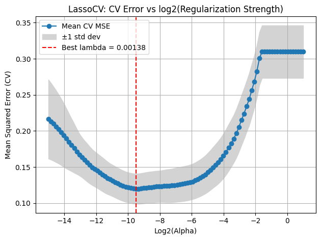

```
Best Lasso regularization parameter: 0.0013762416204132462


Nb of selected variables: 318


Training R2:  0.7318
```

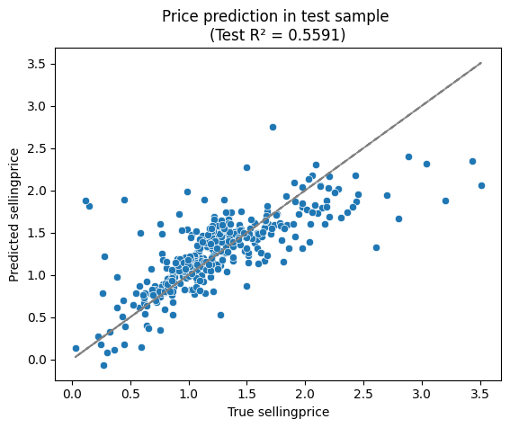

```python
# CV Lasso regression with sklearn LassoCV

lambda_chosen, coefs, Y_train_pred, Y_test_pred = CV_Lasso_from_sklearn(
    X_train, X_test, Y_train, Y_test, nb_cores=5
)

print(f"\nBest Lasso regularization parameter: {lambda_chosen}\n")

print(f"\nNb of selected variables: {(coefs!=0).sum().iloc[0]-1}\n")

selected_vars_for_price_eq = list(coefs.iloc[1:,0][coefs.iloc[1:,0]!=0].index)

print(f"\nTraining R2: {r2_score(Y_train, Y_train_pred): .4f}\n")

plot_true_predicted(Y_test, Y_test_pred, VarName=Y_train.name)
```

```python
with pd.option_context('display.max_rows', 100):
    print(coefs)
```

```
                                                Coefs
(Intercept)                                  1.224553
odometer                                    -0.131533
condition                                    0.079191
year_1999                                   -0.021557
year_2000                                   -0.042824
...                                               ...
interior_gray*interior_other_RivalProducts   0.000000
interior_gray*interior_tan_RivalProducts     0.000000
interior_other*interior_other_RivalProducts  0.006867
interior_other*interior_tan_RivalProducts   -0.000000
interior_tan*interior_tan_RivalProducts      0.006378

[779 rows x 1 columns]
```

### Régression Lasso de l'équation du prix (2) et sélection des variables grâce à la commande glmnet du logiciel R

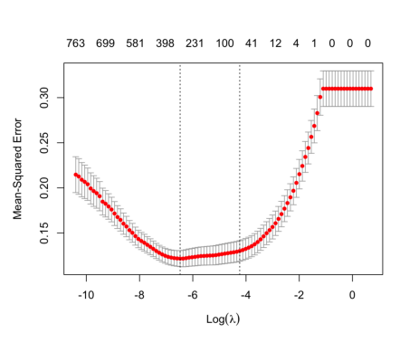

```
Best Lasso regularization parameter: [0.00153938]


Nb of selected variables: 308


Training R2:  0.7246
```

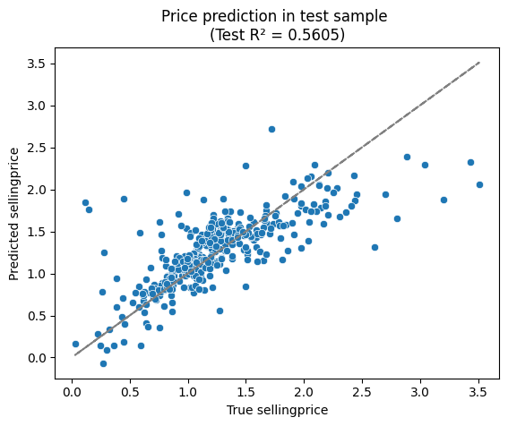

```python
# CV Lasso regression with R glmnet

lambda_chosen,  coefs, Y_train_pred, Y_test_pred = CV_Lasso_from_R_glmnet(
    X_train, X_test, Y_train, Y_test, nb_cores=5
)

print(f"\nBest Lasso regularization parameter: {lambda_chosen}\n")

print(f"\nNb of selected variables: {(coefs!=0).sum().iloc[0]-1}\n")

selected_vars_for_price_eq = list(coefs.iloc[1:,0][coefs.iloc[1:,0]!=0].index)

print(f"\nTraining R2: {r2_score(Y_train, Y_train_pred): .4f}\n")

plot_true_predicted(Y_test, Y_test_pred, VarName=Y_train.name)
```

```python
with pd.option_context('display.max_rows', 100):
    print(coefs)
```

```
                                                Coefs
(Intercept)                                  1.724783
odometer                                    -0.042331
condition                                    0.012395
year_1999                                   -0.328544
year_2000                                   -1.053710
...                                               ...
interior_gray*interior_other_RivalProducts   0.000000
interior_gray*interior_tan_RivalProducts     0.000000
interior_other*interior_other_RivalProducts  0.033222
interior_other*interior_tan_RivalProducts    0.000000
interior_tan*interior_tan_RivalProducts      0.000000

[779 rows x 1 columns]
```

### Régression de la demande après remplacement du prix par sa prédiction exogène obtenue par regression Lasso

```python
price_train_predicted = Y_train_pred.copy()

model, coefs, _ = regress_demand(data_train[endogvars+exogvars], data_train[depvars[-1]], price_train_predicted)
```

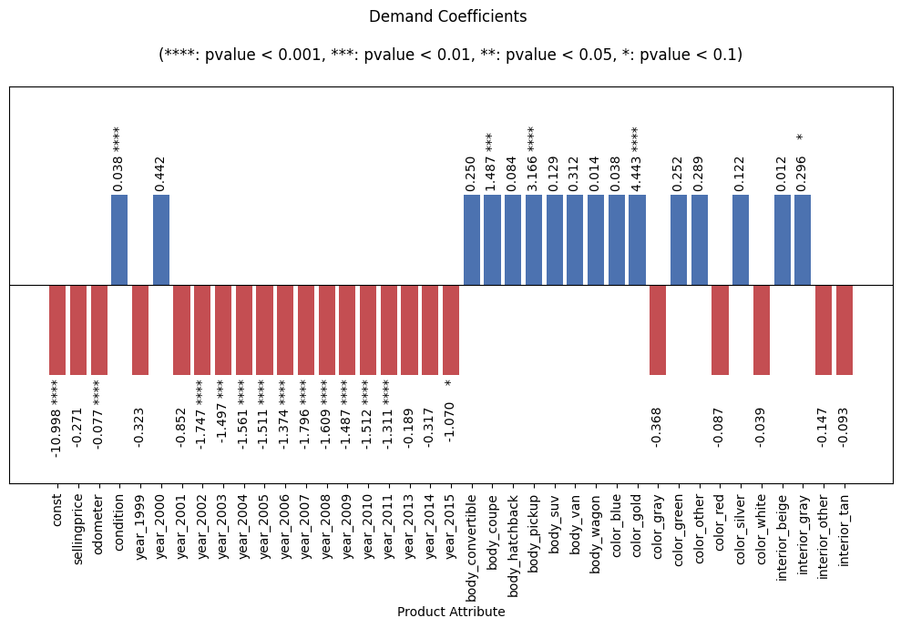

```python
plot_coefs(coefs['coef'], coefs['coef-pvalue'], "Demand Coefficients")
```

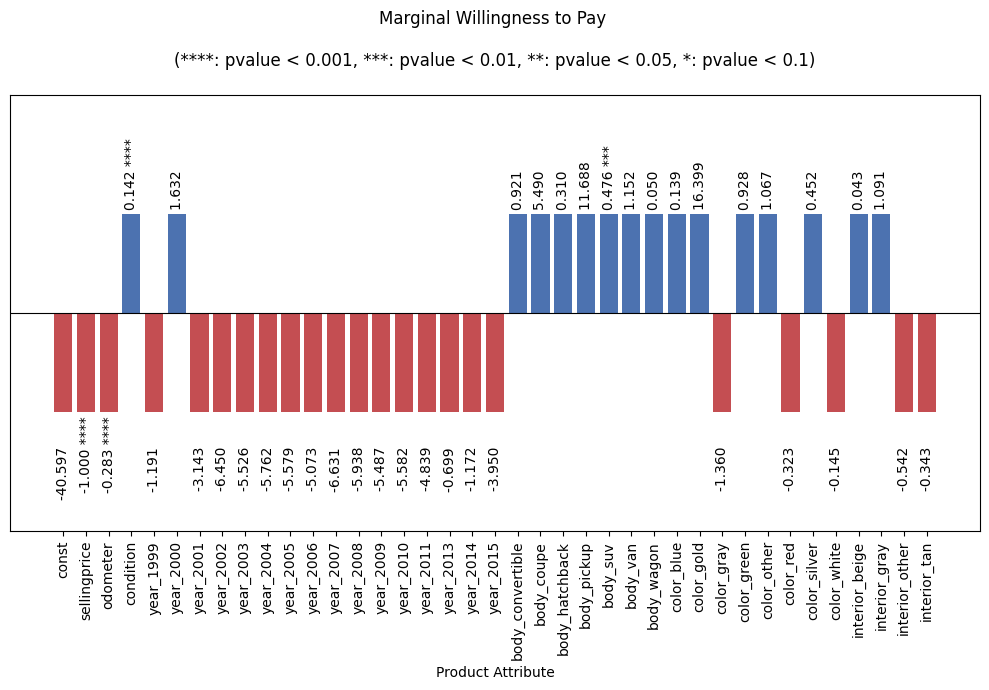

```python
plot_coefs(coefs['wtp'], coefs['wtp-pvalue'], "Marginal Willingness to Pay")
```

# Approximation flexible de $E[P_{jt}|X_{t},Z_{jt}]$ pour relâcher l'hypothèse de linéarité

Les variables contenues dans $X_t$ et $Z_{jt}$ peuvent être utilisées comme instruments pour le prix — c’est-à-dire qu’elles aident à isoler la partie du prix qui n’est pas influencée par la demande. Parmi elles, les variables dans $Z_{jt}$ sont dites exclues de l’équation de demande : elles influencent le prix mais pas directement la demande. Toute fonction construite à partir de ces variables peut donc aussi servir d’instrument. En particulier, la fonction $E[P_{jt} \mid X_t, Z_{jt}]$ — qui correspond à la meilleure prédiction possible du prix à partir de $X_t$ et $Z_{jt}$ — est un instrument particulièrement efficace. Elle capte toute l’information sur le prix que l’on peut extraire de ces variables.

Pour approximer cette fonction de manière flexible, nous allons utiliser deux méthodes issues de l’apprentissage automatique : les forêts aléatoires (random forest) et les réseaux de neurones profonds (deep neural networks).

### Forêts aléatoires utilisant toutes les variables de l'équation du prix

Donner au paramètre $max\_vars\_per\_tree$ la même valeur que le nombre de variables précédemment sélectionnées par la régression linéaire Lasso

```
Training R2:  0.6181
```

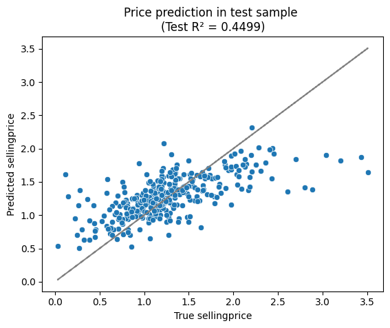

```python
X_train = data_train[exogvars+instrvars]

X_test = data_test[exogvars+instrvars]

Y_train = data_train[endogvars[0]]

Y_test = data_test[endogvars[0]]

Y_train_pred, Y_test_pred = random_forest(X_train, X_test, Y_train, Y_test, nb_cores=5, max_vars_per_tree=len(selected_vars_for_price_eq))

print(f"\nTraining R2: {r2_score(Y_train, Y_train_pred): .4f}\n")

plot_true_predicted(Y_test, Y_test_pred, VarName=Y_train.name)
```

### Forêts aléatoires utilisant seulement les variables sélectionnées prédédemment par la régression Lasso

Donner au paramètre $max\_vars\_per\_tree$ la valeur $1.0$ pour que toutes les variables dans $X\_train$ soient utilisées.

```
Training R2:  0.6305
```

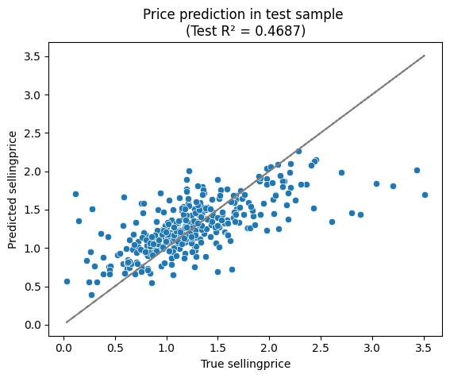

```python
X_train = data_train[selected_vars_for_price_eq]

X_test = data_test[selected_vars_for_price_eq]

Y_train = data_train[endogvars[0]]

Y_test = data_test[endogvars[0]]

Y_train_pred, Y_test_pred = random_forest(X_train, X_test, Y_train, Y_test, nb_cores=5, max_vars_per_tree=1.0)

print(f"\nTraining R2: {r2_score(Y_train, Y_train_pred): .4f}\n")

plot_true_predicted(Y_test, Y_test_pred, VarName=Y_train.name)
```

### Régression de la demande après remplacement du prix par sa prédiction exogène obtenue par forêts aléatoires

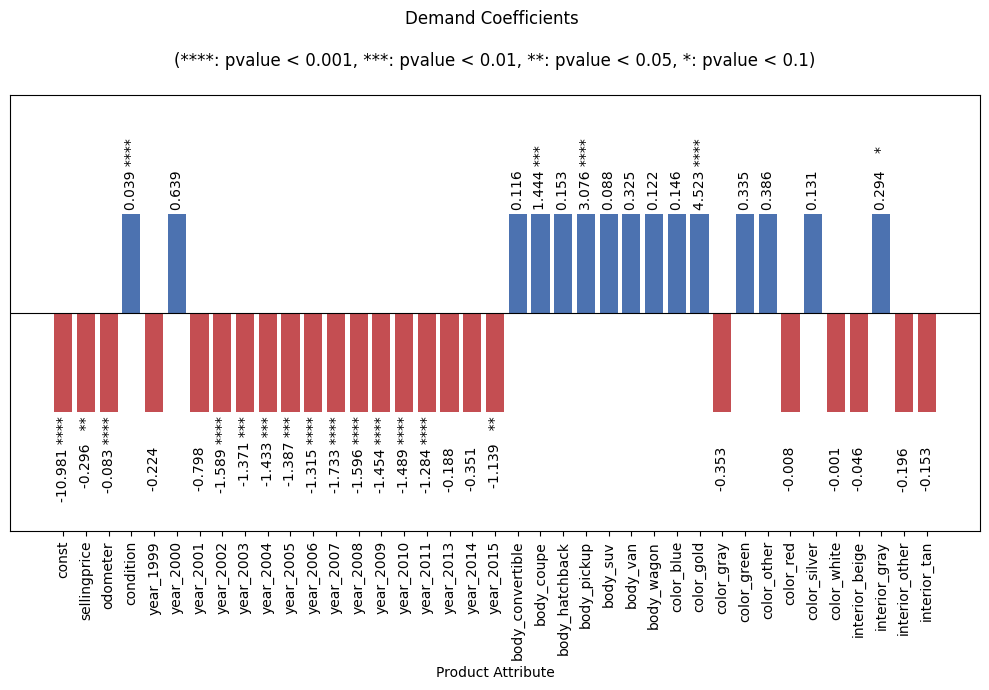

```python
price_train_predicted = Y_train_pred.copy()

model, coefs, _ = regress_demand(data_train[endogvars+exogvars], data_train[depvars[-1]], price_train_predicted)

plot_coefs(coefs['coef'], coefs['coef-pvalue'], "Demand Coefficients")
```

### Réseau de neurone profond utilisant toutes les variables de l'équation du prix

Donner au paramètre "output shape" des couches intermédiaires la même valeur que le nombre de variables précédemment sélectionnées par la régression linéaire Lasso

```
Model: "sequential_3"
```

```
┏━━━━━━━━━━━━━━━━━━━━━━━━━━━━━━━━━┳━━━━━━━━━━━━━━━━━━━━━━━━┳━━━━━━━━━━━━━━━┓
┃ Layer (type)                    ┃ Output Shape           ┃       Param # ┃
┡━━━━━━━━━━━━━━━━━━━━━━━━━━━━━━━━━╇━━━━━━━━━━━━━━━━━━━━━━━━╇━━━━━━━━━━━━━━━┩
│ dense_15 (Dense)                │ (None, 308)            │       239,932 │
├─────────────────────────────────┼────────────────────────┼───────────────┤
│ dense_16 (Dense)                │ (None, 308)            │        95,172 │
├─────────────────────────────────┼────────────────────────┼───────────────┤
│ dense_17 (Dense)                │ (None, 308)            │        95,172 │
├─────────────────────────────────┼────────────────────────┼───────────────┤
│ dense_18 (Dense)                │ (None, 308)            │        95,172 │
├─────────────────────────────────┼────────────────────────┼───────────────┤
│ dense_19 (Dense)                │ (None, 1)              │           309 │
└─────────────────────────────────┴────────────────────────┴───────────────┘
```

```
 Total params: 525,757 (2.01 MB)
```

```
 Trainable params: 525,757 (2.01 MB)
```

```
 Non-trainable params: 0 (0.00 B)
```

```
None
99/99 ━━━━━━━━━━━━━━━━━━━━ 1s 4ms/step
11/11 ━━━━━━━━━━━━━━━━━━━━ 0s 5ms/step

Training R2:  0.9247
```

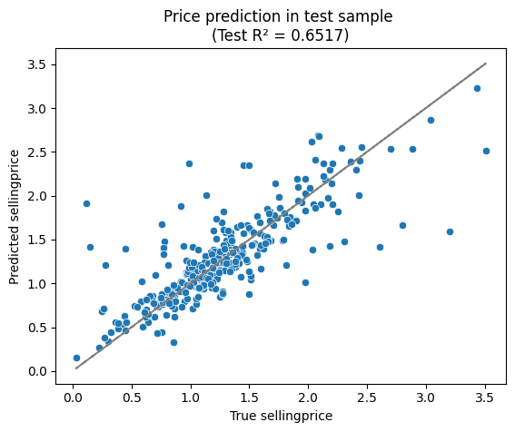

```python
X_train = data_train[exogvars+instrvars]

X_test = data_test[exogvars+instrvars]

Y_train = data_train[endogvars[0]]

Y_test = data_test[endogvars[0]]

Y_train_pred, Y_test_pred = deep_nn(X_train, X_test, Y_train, Y_test, loss='mse', hiden_layer_size=len(selected_vars_for_price_eq))

print(f"\nTraining R2: {r2_score(Y_train, Y_train_pred): .4f}\n")

plot_true_predicted(Y_test, Y_test_pred, VarName=Y_train.name)
```

### Réseau de neurone profond utilisant seulement des variables sélectionnées précédemment par la régression Lasso

Donner au paramètre "output shape" des couches intermédiaires la même valeur que le nombre de variables présentes dans $X\_train$

```
Model: "sequential_4"
```

```
┏━━━━━━━━━━━━━━━━━━━━━━━━━━━━━━━━━┳━━━━━━━━━━━━━━━━━━━━━━━━┳━━━━━━━━━━━━━━━┓
┃ Layer (type)                    ┃ Output Shape           ┃       Param # ┃
┡━━━━━━━━━━━━━━━━━━━━━━━━━━━━━━━━━╇━━━━━━━━━━━━━━━━━━━━━━━━╇━━━━━━━━━━━━━━━┩
│ dense_20 (Dense)                │ (None, 308)            │        95,172 │
├─────────────────────────────────┼────────────────────────┼───────────────┤
│ dense_21 (Dense)                │ (None, 308)            │        95,172 │
├─────────────────────────────────┼────────────────────────┼───────────────┤
│ dense_22 (Dense)                │ (None, 308)            │        95,172 │
├─────────────────────────────────┼────────────────────────┼───────────────┤
│ dense_23 (Dense)                │ (None, 308)            │        95,172 │
├─────────────────────────────────┼────────────────────────┼───────────────┤
│ dense_24 (Dense)                │ (None, 1)              │           309 │
└─────────────────────────────────┴────────────────────────┴───────────────┘
```

```
 Total params: 380,997 (1.45 MB)
```

```
 Trainable params: 380,997 (1.45 MB)
```

```
 Non-trainable params: 0 (0.00 B)
```

```
None
99/99 ━━━━━━━━━━━━━━━━━━━━ 0s 4ms/step
11/11 ━━━━━━━━━━━━━━━━━━━━ 0s 9ms/step

Training R2:  0.9269
```

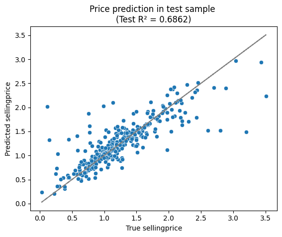

```python
X_train = data_train[selected_vars_for_price_eq]

X_test = data_test[selected_vars_for_price_eq]

Y_train = data_train[endogvars[0]]

Y_test = data_test[endogvars[0]]

Y_train_pred, Y_test_pred = deep_nn(X_train, X_test, Y_train, Y_test, loss='mse', hiden_layer_size=len(selected_vars_for_price_eq))

print(f"\nTraining R2: {r2_score(Y_train, Y_train_pred): .4f}\n")

plot_true_predicted(Y_test, Y_test_pred, VarName=Y_train.name)
```

### Régression de la demande après remplacement du prix par sa prédiction exogène obtenue par réseau de neurones

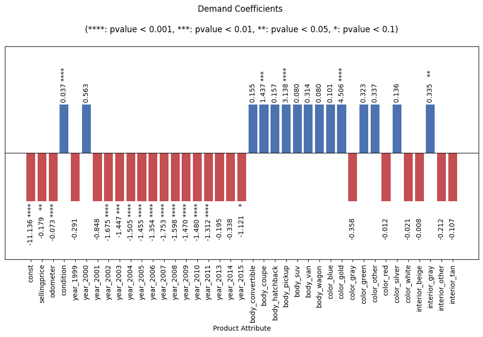

```python
price_train_predicted = Y_train_pred.copy()

model, coefs, _ = regress_demand(data_train[endogvars+exogvars], data_train[depvars[-1]], price_train_predicted)

plot_coefs(coefs['coef'], coefs['coef-pvalue'], "Demand Coefficients")
```

# Réduction de dimension des prédicteurs du prix: Analyse en Composantes Principales, ACP (PCA en anglais)

On applique l'ACP pour reduire la dimension des predicteurs du prix. La réduction du nombre de variables pourrait nous donner plus de flexibilité dans la prediction du prix.

Soit $U$ la matrice des prédicteurs du prix (par exemple les variables $X$ et $Z$). L'analyse en composantes principales (ACP) consiste à trouver une matrice orthonormée $P$ telle que $V = UP$ soit une transformation linéaire de $U$ vers un nouvel espace dans lequel les composantes sont non corrélées et ordonnées par variance décroissante.

La matrice $V$ est appelée matrice des composantes principales. Si l'on conserve les $v$ premières colonnes de $V$, on obtient une représentation de $U$ dans un espace de dimension réduite qui préserve le plus possible la variance initiale. Cette représentation est optimale au sens où aucune autre combinaison de $v$ vecteurs quelconques ne permet de conserver davantage de variance.

### Réduisons l'espace des predicteurs du prix à un espace qui préserve 99% des variations de l'espace initial

```
The first 310 components have a total variance ratio of 0.99
```

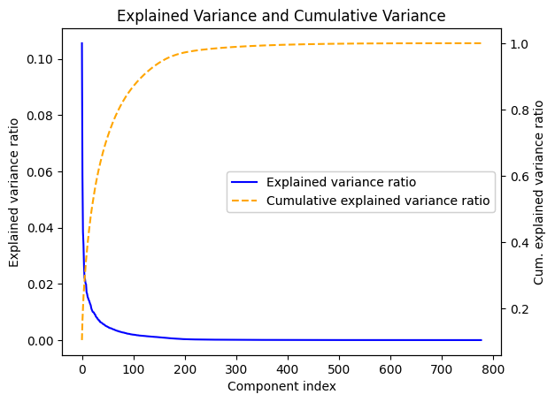

```python
X_train = data_train[exogvars+instrvars]

X_test = data_test[exogvars+instrvars]

Y_train = data_train[endogvars[0]]

Y_test = data_test[endogvars[0]]

X_train_pca, X_test_pca = pca(X_train, X_test, variance_ratio_preserved=0.99)
```

### Prédiction du prix par forêts aléatoires sur les nouvelles variables de l'espace réduit

```
Training R2:  0.4205
```

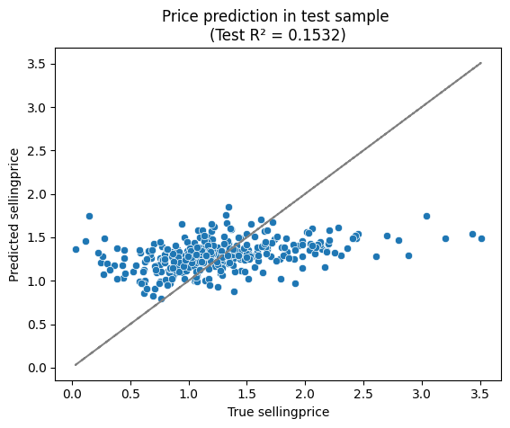

```python
X_train = X_train_pca.copy()

X_test = X_test_pca.copy()

Y_train = data_train[endogvars[0]]

Y_test = data_test[endogvars[0]]

Y_train_pred, Y_test_pred = random_forest(X_train, X_test, Y_train, Y_test, nb_cores=5, max_vars_per_tree=1.0)

print(f"\nTraining R2: {r2_score(Y_train, Y_train_pred): .4f}\n")

plot_true_predicted(Y_test, Y_test_pred, VarName=Y_train.name)
```

### Régression de la demande après remplacement du prix par sa prédiction exogène obtenue par la nouvelle forêt aléatoire précédente

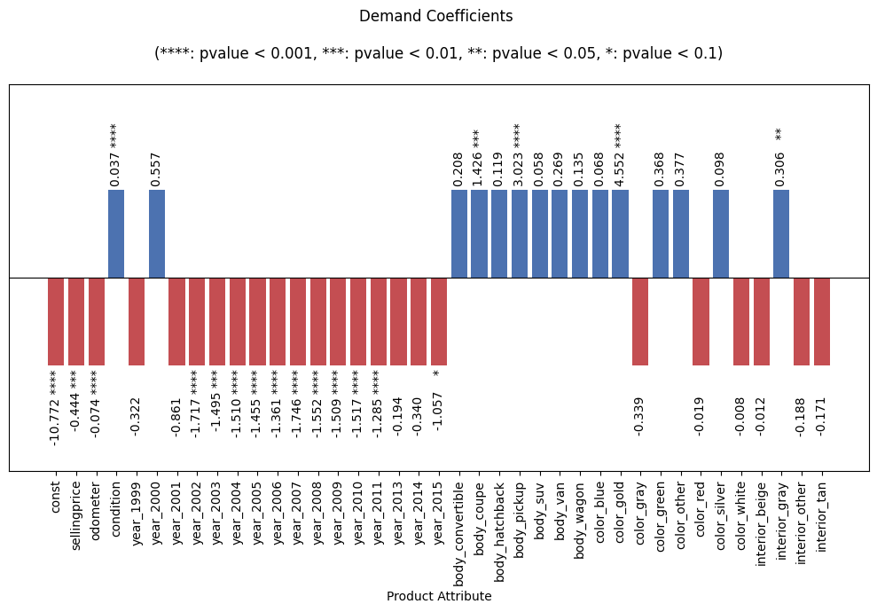

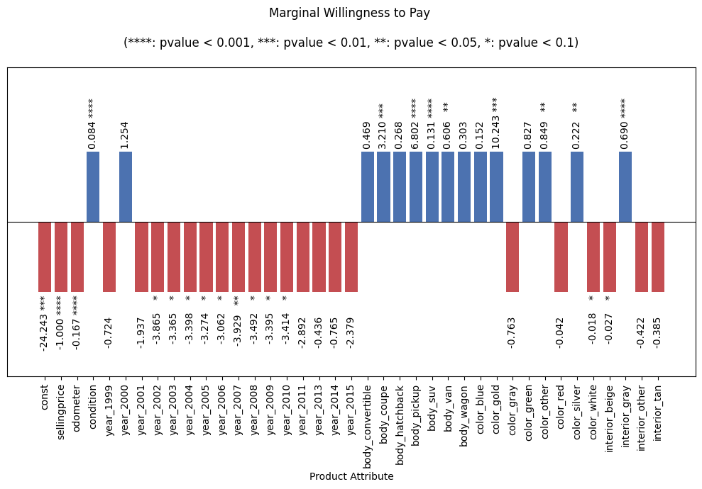

```python
price_train_predicted = Y_train_pred.copy()

model, coefs, _ = regress_demand(data_train[endogvars+exogvars], data_train[depvars[-1]], price_train_predicted)

plot_coefs(coefs['coef'], coefs['coef-pvalue'], "Demand Coefficients")

plot_coefs(coefs['wtp'], coefs['wtp-pvalue'], "Marginal Willingness to Pay")
```

### Prédiction du prix par réseau de neurones sur les nouvelles variables de l'espace réduit

```
Model: "sequential_5"
```

```
┏━━━━━━━━━━━━━━━━━━━━━━━━━━━━━━━━━┳━━━━━━━━━━━━━━━━━━━━━━━━┳━━━━━━━━━━━━━━━┓
┃ Layer (type)                    ┃ Output Shape           ┃       Param # ┃
┡━━━━━━━━━━━━━━━━━━━━━━━━━━━━━━━━━╇━━━━━━━━━━━━━━━━━━━━━━━━╇━━━━━━━━━━━━━━━┩
│ dense_25 (Dense)                │ (None, 310)            │        96,410 │
├─────────────────────────────────┼────────────────────────┼───────────────┤
│ dense_26 (Dense)                │ (None, 310)            │        96,410 │
├─────────────────────────────────┼────────────────────────┼───────────────┤
│ dense_27 (Dense)                │ (None, 310)            │        96,410 │
├─────────────────────────────────┼────────────────────────┼───────────────┤
│ dense_28 (Dense)                │ (None, 310)            │        96,410 │
├─────────────────────────────────┼────────────────────────┼───────────────┤
│ dense_29 (Dense)                │ (None, 1)              │           311 │
└─────────────────────────────────┴────────────────────────┴───────────────┘
```

```
 Total params: 385,951 (1.47 MB)
```

```
 Trainable params: 385,951 (1.47 MB)
```

```
 Non-trainable params: 0 (0.00 B)
```

```
None
99/99 ━━━━━━━━━━━━━━━━━━━━ 0s 3ms/step
11/11 ━━━━━━━━━━━━━━━━━━━━ 0s 4ms/step

Training R2:  0.9231
```

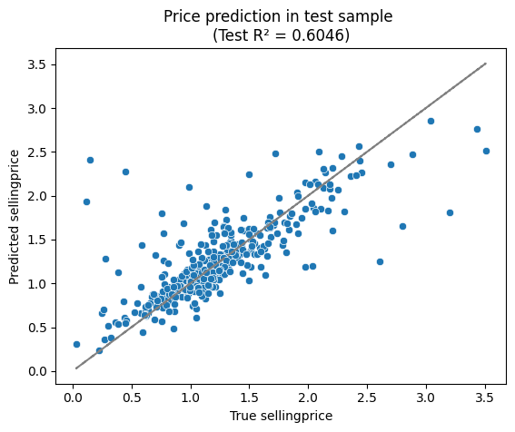

```python
X_train = X_train_pca.copy()

X_test = X_test_pca.copy()

Y_train = data_train[endogvars[0]]

Y_test = data_test[endogvars[0]]

Y_train_pred, Y_test_pred = deep_nn(X_train, X_test, Y_train, Y_test, loss='mse', hiden_layer_size=X_train.shape[1])

print(f"\nTraining R2: {r2_score(Y_train, Y_train_pred): .4f}\n")

plot_true_predicted(Y_test, Y_test_pred, VarName=Y_train.name)
```

### Régression de la demande après remplacement du prix par sa prédiction exogène obtenue par le nouveau réseau neuronal précédent

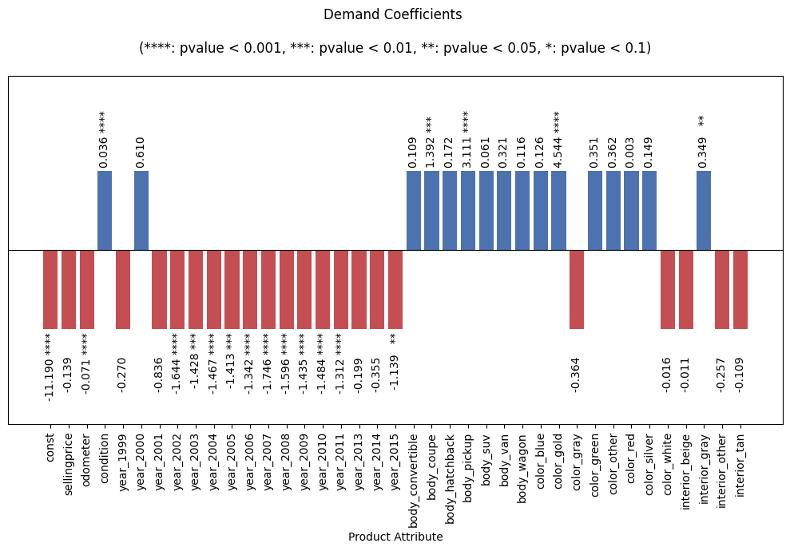

```python
price_train_predicted = Y_train_pred.copy()

model, coefs, _ = regress_demand(data_train[endogvars+exogvars], data_train[depvars[-1]], price_train_predicted)

plot_coefs(coefs['coef'], coefs['coef-pvalue'], "Demand Coefficients")
```

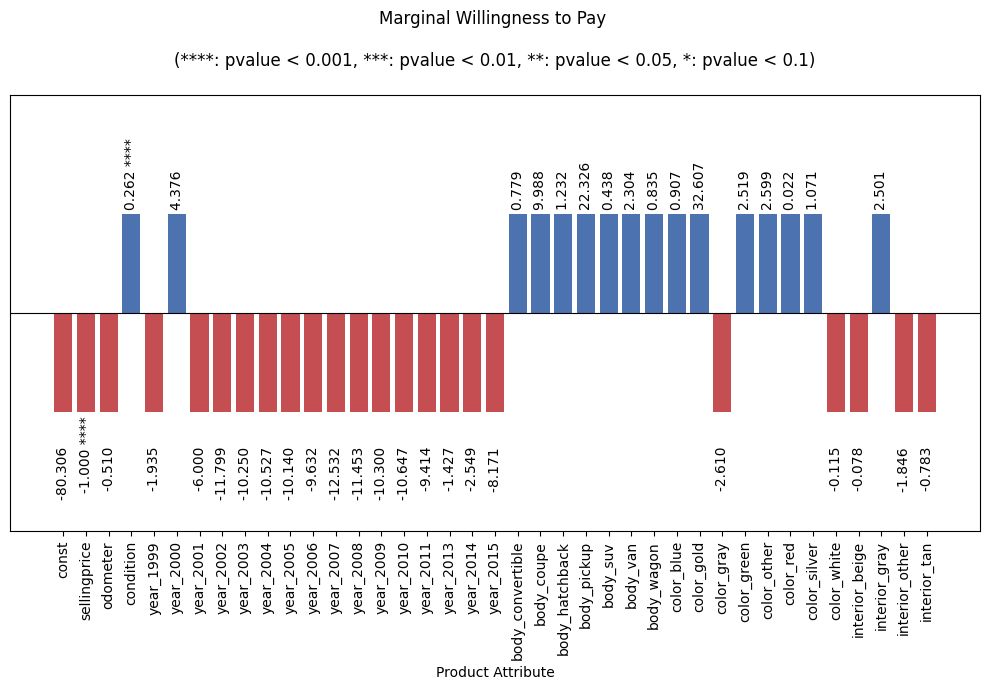

```python
plot_coefs(coefs['wtp'], coefs['wtp-pvalue'], "Marginal Willingness to Pay")
```